# HW1

# Sport Forecasting

In recent years Sport Forecasting became very popular. In this document the behaviour of betting companies will be analyzied. We will try to understand how bookmakers are good at deciding odds. An then we will focus on one or two bookmakers’ decisions.

## Data Preperation

We have two data available in hand. One consists of match details and the other is the odd information of different bets of different bookmakers for matches.

The data is read from rds files a it is shown below.

```r
Matches=readRDS('C:/Users/eda.yildiz/Downloads/df9b1196-e3cf-4cc7-9159-f236fe738215_matches.rds', refhook = NULL)
Odds=readRDS('C:/Users/eda.yildiz/Downloads/df9b1196-e3cf-4cc7-9159-f236fe738215_odd_details.rds', refhook = NULL)
```

Data cleaning is an important step in analysing big data. After reading the data, duplicate records and possible missing records are checked.

In the matches data some matchIDs are duplicated. It requires cleaning because it can lead wrong results especially in join operators There is not any match that finished but has no odd information.

I also deleted the matches that has not started yet.

## Question 1-a

In this question we are asked to analyze how good are the bookmakers at deciding over/under odds.A scatter plot of implied “over” probability average versusu the fraction of games finished over the corresponding probability range is needed for both Initial odds and finalodds for bookmakers.

Since we need to use only odds information that are in type ‘over-under’ and has 2.5 totalhandicap,I firstly filtered the data to what I needed. Then probability calculations are done. An odd is calculated as the reciprocal of the probability. For each bookmaker final and initial odds are stored in two tables.

These steps can be seen from below.

```r
#Needed Data is filtered
Data=Data[totalhandicap==2.5 & betType=='ou']
Data$Count=NULL

#Calculation of Probabilities
Data[,Prob:=1/odd]

#Obtain last and intiial odds for each bookmaker and match
FinalOdds=Data[order(-OddDate),Count:=1:.N,c('bookmaker','oddtype','betType','matchId','totalhandicap')][Count==1]
InitialOdds=Data[order(OddDate),Count:=1:.N,c('bookmaker','oddtype','betType','matchId','totalhandicap')][Count==1]


#Probability Normalization
FinalOdds[,SumOfProb:=sum(Prob),list(bookmaker,betType,matchId,totalhandicap)]
FinalOdds[,NormalizedProb:=Prob/SumOfProb]
InitialOdds[,SumOfProb:=sum(Prob),list(bookmaker,betType,matchId,totalhandicap)]
InitialOdds[,NormalizedProb:=Prob/SumOfProb]
```

In order to determine the probability ranges Histogram for the odds is plotted. As it can be seen from below the “hist” function is used. As an input I give 10 classes.

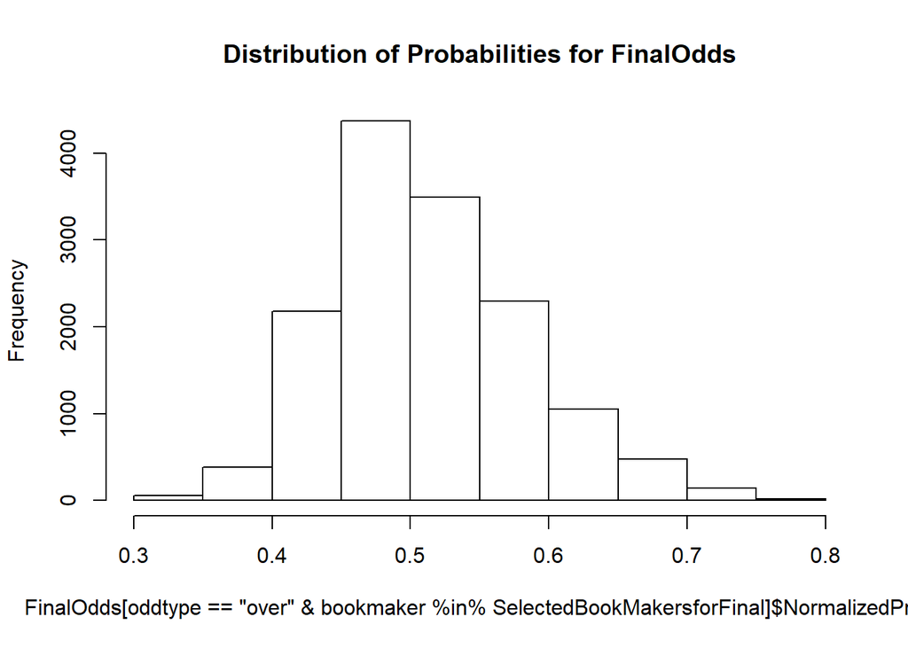

```r
BookmakersForFinal=as.data.table(unique(FinalOdds[,list(Count=.N),c("bookmaker")]))
SelectedBookMakersforFinal=BookmakersForFinal[order(-Count)][1:5]$bookmaker

HistogramFinals=hist(FinalOdds[oddtype=='over' & bookmaker %in% SelectedBookMakersforFinal]$NormalizedProb,nclass =10,main="Distribution of Probabilities for FinalOdds")
```

These analysis are conducted for 5 bookmakers. Betsafe, Betsson, Betway, Interwetten and bet365 are selected because they are the top 5 having the largest number of odds in the data. The histogram can be seen from above.

As you can see from the plots from below, bookmakers offer better odds when time passes. Final Odds are better than the initials (the dots on the plots are distributed around the x=y line with less error)

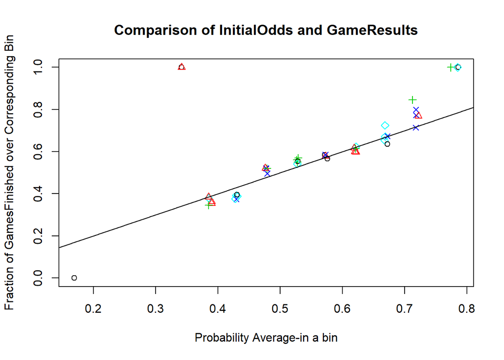

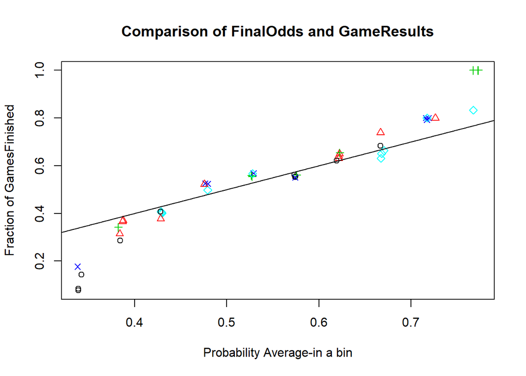

# Question 1-b

After observing that the final odds are better than the initials I will continue my analysis with the final odds. Bookmaker “Interwetten” is selected to determine how the company is consistently good at determining the “over” probabilities during the time-period.

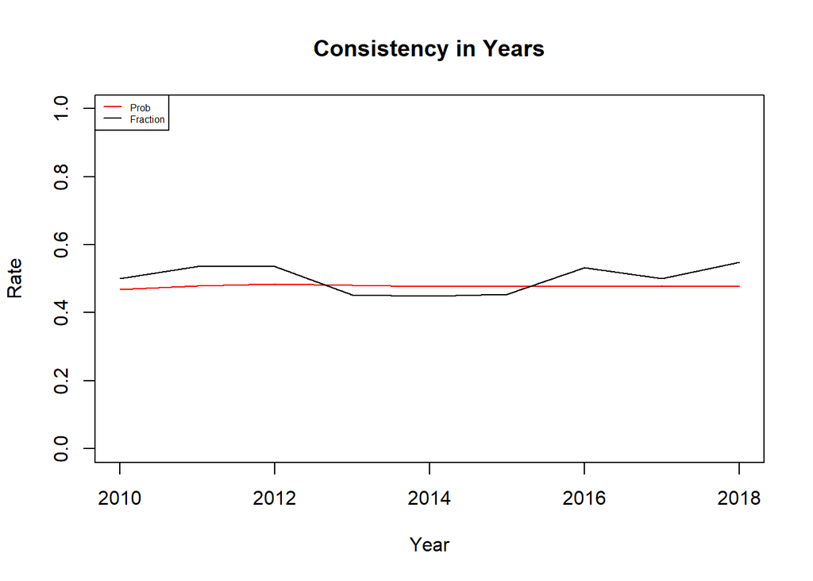

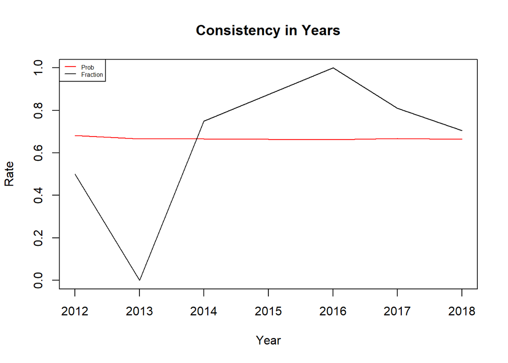

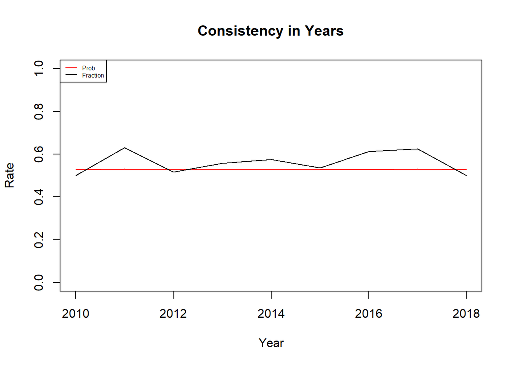

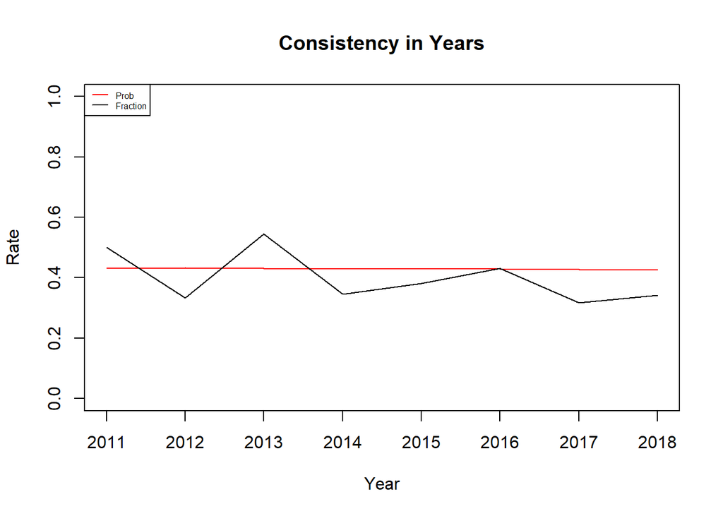

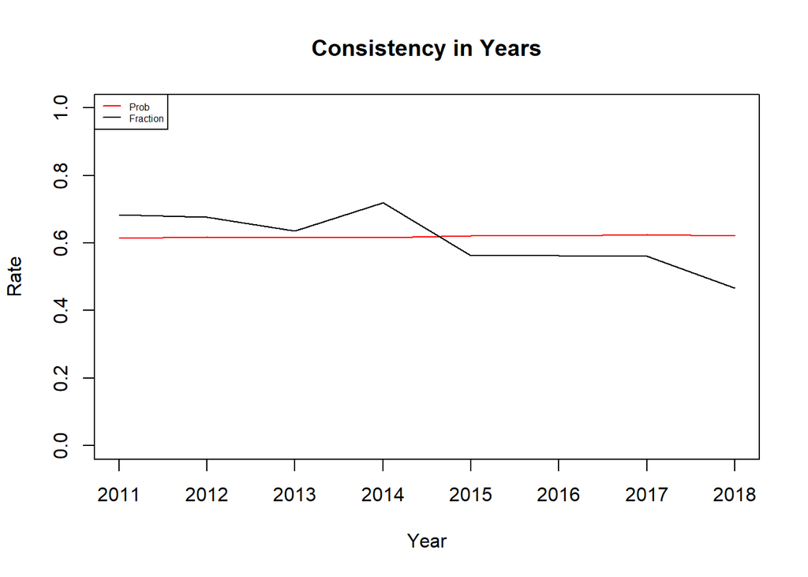

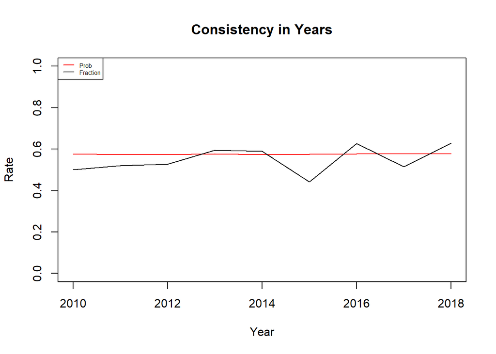

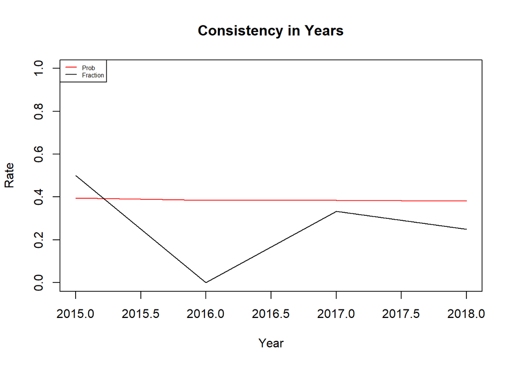

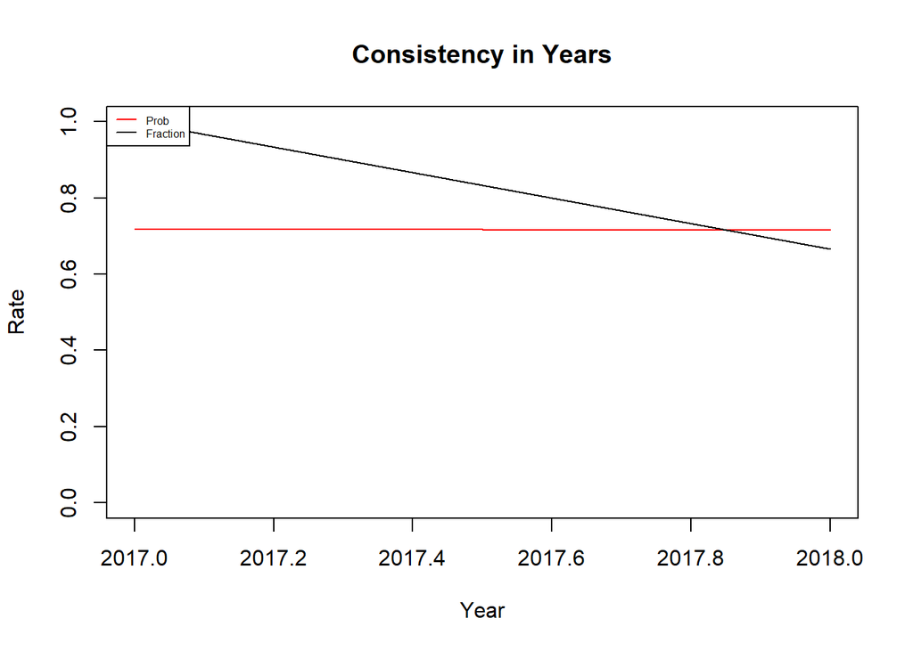

## Question2

Odds are are filtered. Only the Home Win case will be analyzed.

Time axis will be the time period from the mindate of odds and max date of odds for each match. In other words the time difference is normalized. Code can be seen from below.

```r
GameResult=Odds[MatchesCleaned][betType=='1x2' & bookmaker==BM]
GameResult$totalhandicap=NULL
GameResult[,OddDate:=anytime(OddDate)]
GameResult[oddtype=='odd1',Count:=.N,list(matchId,bookmaker)]

GameRes=GameResult[Count>3 &oddtype=='odd1']

GameRes[,MinDate:= min(OddDate) ,list(matchId,bookmaker)]
GameRes[,MaxDate:= max(OddDate) ,list(matchId,bookmaker)]
GameRes[,OddTimePeriod :=as.integer(difftime(OddDate, MinDate, tz="GMT",units = "secs"))]
GameRes[,OddTimeDiff :=as.integer(difftime(MaxDate, MinDate, tz="GMT",units = "secs"))]
GameRes$OddTimeDiff2=NULL
GameRes[,NormTime :=OddTimePeriod/OddTimeDiff]

Matchesfrom= as.data.table(unique(GameRes[,c('matchId','Count'),with=FALSE]))
Matchesfrom[order(-Count),rank:=1:.N]
MatchT=Matchesfrom[rank<50]

GameResFiltered=GameRes[odd<4]
```

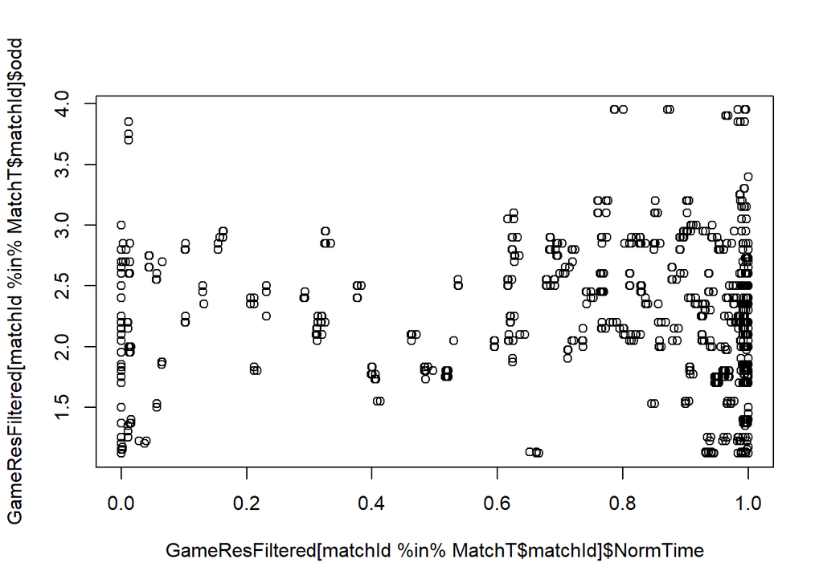

As it can be seen from the graph as it is closer to the oddEnding time more odds are offered. And the frequency of the changes increases.